# Final Exam

Lawrence Fung

Before completing this .rmd file, please read “The Measurement of Same-Sex Unmarried Partner Couples in the 2000 Census” by Dan Black et al. (in this project folder; also avaialble at https://escholarship.org/uc/item/72r1q94b). You will need information from that article to answer the questions below.

**In all visualizations, make sure that you are not using the default theme or default colors. All visualizations should be presentation-quality, so no variable names should appear in your graphs.**

Run the following code block as-is to load packages and data.

```r
library(tidyverse)
library(ggalluvial)

ipums <- readRDS("final.RDS")
```

## Getting started

Use the `names()` function to see which variables are in the data frame and another function (of your choice) to see which year(s) is/are in the data frame.

```r
names(ipums)
```

```
 [1] "YEAR"      "DATANUM"   "SERIAL"    "HHWT"      "GQ"        "PERNUM"    "PERWT"     "NCHILD"    "RELATE"    "RELATED"   "SEX"       "AGE"       "MARST"     "RACE"      "RACED"
[16] "HISPAN"    "HISPAND"   "BPL"       "BPLD"      "LANGUAGE"  "LANGUAGED" "QMARST"
```

```r
#Which function(s) will show you which year(s) is/are in the data frame?
table(ipums$YEAR)
```

```
   1990    2000
2500052 2818644
```

There are two new variables we have not worked with before: `LANGUAGE` (and `LANGUAGED`) and `QMARST`. Looking at the codebook (“final.txt” in this folder) and/or the ipums documentation online (at usa.ipums.org), describe these variables:

> > LANGUAGE records the langauge that the individual spoke at home, if the individual did not speak English at home. LANGUAGED records more detailed information like the dialect or region of the language. QMARST records the allocation of the data entry in MARST, the marital status, as a data quality flag.

## Bar Braphs: Married and unmarried same- and different-sex couples

Follow the steps below to make a set of stacked bar graphs showing the number of same- and different-sex married and unmarried couples in the 1990 and 2000 censuses. Year will be on the x-axis and number of couples on the y-axis; color will indiate whether the couple is married or unmarried and facets will indicate whether the members of the couple are different sex or same sex.

1. We will only be including couples where one member is the head/householder. Make two data frames, one of all household heads (call it `heads`) and one of all married and unmarried partners of household heads (call it `partners`).

```r
heads <- ipums %>% filter(RELATE == 1)
partners <- ipums %>% filter(RELATE == 2 | RELATED == 1114)
```

2. Join the `heads` and `partners` data frames together to create a data frame called `couples`. Create a **factor** variable called `SSEX` indicating whether the partners are of the same sex or different sexes and a **factor variable** called `MARRIED` indicating whether the partners are married or unmarried. **Test your new variables.**

```r
couples <- inner_join(heads, partners, by = c("SERIAL", "YEAR")) %>%
  mutate(MARRIED = factor(RELATE.y == 2, labels = c("Unmarried", "Married")),
         SSEX = factor(SEX.x == SEX.y, labels = c("Different Sex", "Same Sex")))


#Test
is.factor(couples$SSEX)
```

```
[1] TRUE
```

```r
is.factor(couples$MARRIED)
```

```
[1] TRUE
```

```r
table(couples$SEX.x, couples$SEX.y, couples$SSEX)
```

```
, ,  = Different Sex


          1       2
  1       0 1046497
  2  124906       0

, ,  = Same Sex


          1       2
  1    4070       0
  2       0    3877
```

```r
table(couples$MARRIED, couples$RELATE.y)
```

```
                  2      11
  Unmarried       0   81743
  Married   1097607       0
```

3. Make a bar graph with `YEAR` on the x-axis and number of couples on the y-axis, with fill showing whether couples are married or not, faceted by whether couples are same sex or different sex. Weight by the head’s `PERWT`. **Allow each facet to have a different y-axis scale.**

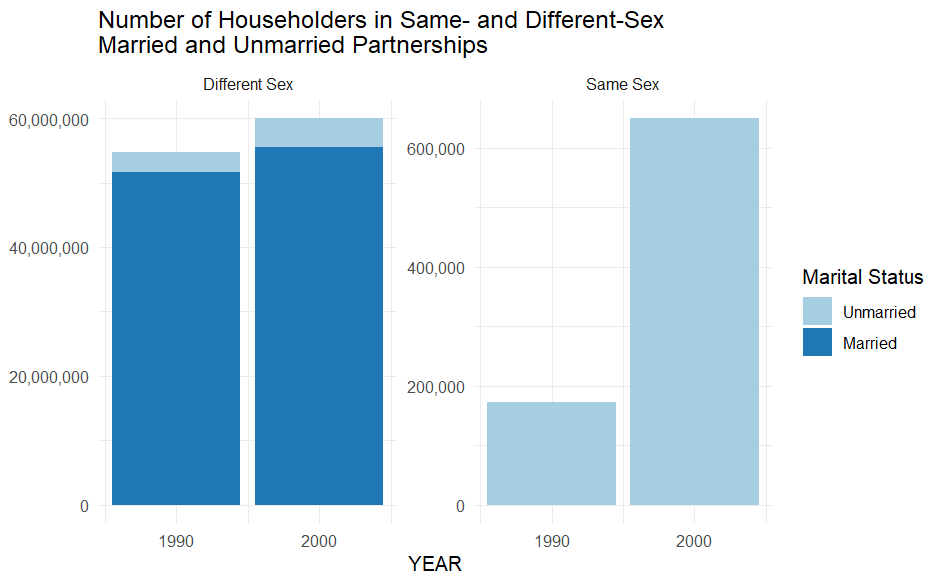

```r
couples %>% ggplot(aes(YEAR, fill = MARRIED, weight = PERWT.x)) +
            geom_bar() +
            facet_wrap(~SSEX, scales = "free_y") +
            theme_minimal() +
            scale_y_continuous(labels = scales::comma) + # this converts the scientific notations
            scale_x_continuous(breaks = seq(1990, 2000, 10)) +
            scale_fill_brewer(palette = "Paired") +
            labs(x = "YEAR", y = NULL, fill = "Marital Status", title = "Number of Householders in Same- and Different-Sex \nMarried and Unmarried Partnerships")
```

Why are there no same-sex married couples?

> > In 1990, the census thought that same-sex couples are a logical contradiction and changed the sex of the “husband/wife”. In 2000, the census changed the relationship status of same-sex couples to “unmarried partner”. Because of the Defense of Marriage Act in 1996, the federal government did not recognize same-sex married couples in the 2000 Census. Therefore, we do not see same-sex couples in 1990 and 2000.

## Line graphs: Allocation

For the second visualization, you are going to follow the steps below to graph the percentage of same- and different-sex **unmarried** couples in which the marital status of one or both partners was *allocated*, meaning changed (from married to unmarried) by the Census Bureau. **If a person’s marital status was allocated, they will have a value of QMARST greater than 0.**

1. Add a variable to the `couples` data frame called `ALLOCATED` that indicates whether one (or both) partner’s marital status was allocated. It should be a **logical** variable, taking a value of `TRUE` if either partner’s marital status was allocated. Be sure to test your new variable.

```r
couples$ALLOCATED <- (couples$QMARST.x > 0 | couples$QMARST.y > 0)

#Test:
table(couples$QMARST.x, couples$QMARST.y, couples$ALLOCATED)
```

```
, ,  = FALSE


          0       4
  0 1167635       0
  4       0       0

, ,  = TRUE


          0       4
  0       0    5084
  4    1735    4896
```

```r
is.logical(couples$ALLOCATED)
```

```
[1] TRUE
```

2. Make a line graph for **unmarried couples only**, showing the percent of couples that had their marital status allocated in 1990 and 2000 (`YEAR` will be on the x-axis and the percent of couples will be on the y-axis). Use color to indicate whether the couple was same-sex or different-sex. Weight by head’s `PERWT`.

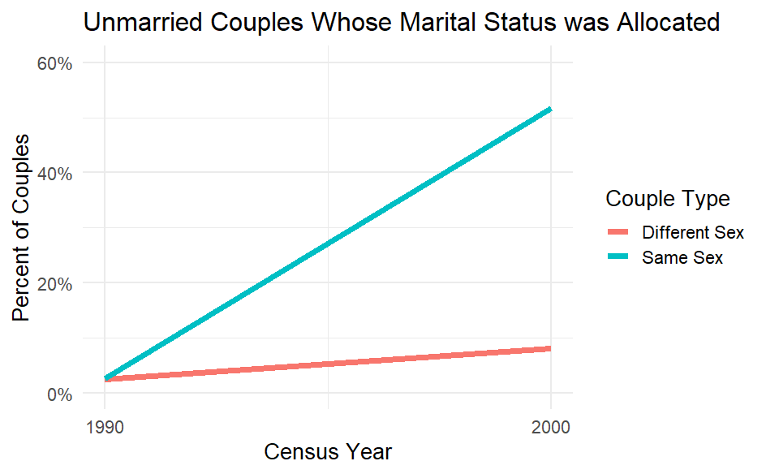

```r
couples %>% filter(MARRIED == "Unmarried") %>%
  group_by(YEAR, SSEX) %>%
  count(ALLOCATED, wt = PERWT.x) %>%
  mutate(PCT = n/sum(n)) %>%
  filter(ALLOCATED == TRUE) %>%
  ggplot(aes(x= YEAR, y = PCT, color = SSEX)) +
  geom_line(size = 2) +
  theme_minimal(base_size = 15) +
  scale_y_continuous(labels = scales::percent, lim = c(0,0.6))+
  scale_x_continuous(breaks = seq(1990,2000,10)) +
  labs(x = "Census Year", y = "Percent of Couples", color = "Couple Type", title = "Unmarried Couples Whose Marital Status was Allocated") # +
```

```r
  # scale_color_manual(values = wes_palette("Darjeeling1", 4) [1:4])
```

Why did the rate of allocation increase between 1990 and 2000?

> > Because of new coding procedure adopted by the census in 2000, the relationship of same-sex couples was changed from “married” to “unmarried” if one partner was a “husband/wife” to another “husband/wife”, but the sex of the couples were maintained.

## Population pyramids: Age and sex of Person 1

Follow the steps below to create population pyramids for **Person 1 only**, classified into **four relationship categories: married different-sex, unmarried different-sex, allocated same-sex, unallocated same-sex**.

1. Add two new **factor** variables to the `couples` data frame. The first will be called `TYPE` and will indicate which category a couple belongs to (of the categories listed above). The second will be called AGEG and will indicate the age of Person 1, grouped into eight categories: younger than 20, ten-year age groups through 79, and 80+. Test your new variables. Keep in mind that creating the `TYPE` variable will require you to consider values of three existing variables (`SSEX`, `MARRIED`, and `ALLOCATED`), so you will need to test it against each of these existing variables.

```r
agegrp <- "<20"

for (i in 2:7) {    # go through this loop 7 times
    agegrp <- c(agegrp, str_c(i, "0-", i, "9")) # c() helps add new vectors to the variable
}
agegrp <- c(agegrp, "80+") # manually add the last label to the variable in a vector
agegrp
```

```
[1] "<20"   "20-29" "30-39" "40-49" "50-59" "60-69" "70-79" "80+"
```

```r
couples <- couples %>% mutate(TYPE = factor(ifelse(MARRIED == "Married" & SSEX == "Different Sex", "Married Different-Sex",
                                           ifelse(MARRIED == "Unmarried" & SSEX == "Different Sex", "Unmarried Different-Sex",
                                           ifelse(ALLOCATED == TRUE & SSEX == "Same Sex", "Allocated Same-Sex",
                                            ifelse(ALLOCATED == FALSE & SSEX == "Same Sex", "Unallocated Same-Sex", "What"))))),
                              AGEG = factor(ifelse(AGE.x > 79, 8, AGE.x %/% 10), labels = agegrp)) # matching the sequence made in ifelse to the sequence according to AGEG



#Test your new variables:
  # Testing TYPE
  is.factor(couples$TYPE)
```

```
[1] TRUE
```

```r
  table(couples$TYPE)
```

```
     Allocated Same-Sex   Married Different-Sex    Unallocated Same-Sex Unmarried Different-Sex
                   3487                 1097607                    4460                   73796
```

```r
  couples %>% filter(TYPE == "What") %>% select(TYPE, SSEX, MARRIED, ALLOCATED)
```

| TYPE | SSEX | MARRIED | ALLOCATED |
| --- | --- | --- | --- |

```r
  # 3-way table to test
  table(couples$MARRIED, couples$SSEX, couples$TYPE)
```

```
, ,  = Allocated Same-Sex


            Different Sex Same Sex
  Unmarried             0     3487
  Married               0        0

, ,  = Married Different-Sex


            Different Sex Same Sex
  Unmarried             0        0
  Married         1097607        0

, ,  = Unallocated Same-Sex


            Different Sex Same Sex
  Unmarried             0     4460
  Married               0        0

, ,  = Unmarried Different-Sex


            Different Sex Same Sex
  Unmarried         73796        0
  Married               0        0
```

```r
  table(couples$ALLOCATED, couples$SSEX, couples$TYPE)
```

```
, ,  = Allocated Same-Sex


        Different Sex Same Sex
  FALSE             0        0
  TRUE              0     3487

, ,  = Married Different-Sex


        Different Sex Same Sex
  FALSE       1093650        0
  TRUE           3957        0

, ,  = Unallocated Same-Sex


        Different Sex Same Sex
  FALSE             0     4460
  TRUE              0        0

, ,  = Unmarried Different-Sex


        Different Sex Same Sex
  FALSE         69525        0
  TRUE           4271        0
```

```r
  # 2-way table to test
  table(couples$MARRIED, couples$TYPE)
```

```
            Allocated Same-Sex Married Different-Sex Unallocated Same-Sex Unmarried Different-Sex
  Unmarried               3487                     0                 4460                   73796
  Married                    0               1097607                    0                       0
```

```r
  table(couples$SSEX, couples$TYPE)
```

```
                Allocated Same-Sex Married Different-Sex Unallocated Same-Sex Unmarried Different-Sex
  Different Sex                  0               1097607                    0                   73796
  Same Sex                    3487                     0                 4460                       0
```

```r
  table(couples$ALLOCATED, couples$TYPE)
```

```
        Allocated Same-Sex Married Different-Sex Unallocated Same-Sex Unmarried Different-Sex
  FALSE                  0               1093650                 4460                   69525
  TRUE                3487                  3957                    0                    4271
```

```r
  # Testing AGEG
  table(couples$AGE.x, couples$AGEG)
```

```
       <20 20-29 30-39 40-49 50-59 60-69 70-79   80+
  15    20     0     0     0     0     0     0     0
  16    93     0     0     0     0     0     0     0
  17   196     0     0     0     0     0     0     0
  18   791     0     0     0     0     0     0     0
  19  2051     0     0     0     0     0     0     0
  20     0  3741     0     0     0     0     0     0
  21     0  5371     0     0     0     0     0     0
  22     0  7157     0     0     0     0     0     0
  23     0  9504     0     0     0     0     0     0
  24     0 11685     0     0     0     0     0     0
  25     0 14589     0     0     0     0     0     0
  26     0 16843     0     0     0     0     0     0
  27     0 19026     0     0     0     0     0     0
  28     0 20924     0     0     0     0     0     0
```

[output cut: 64 more lines]

2. **For 2000 only**, make population pyramids **for Person 1**, using facets to indicate relationship type. Bars should represent a **percent** of all Person 1 in a given relationship type, such that all bars (in all facets) should sum to 1 or 100%.

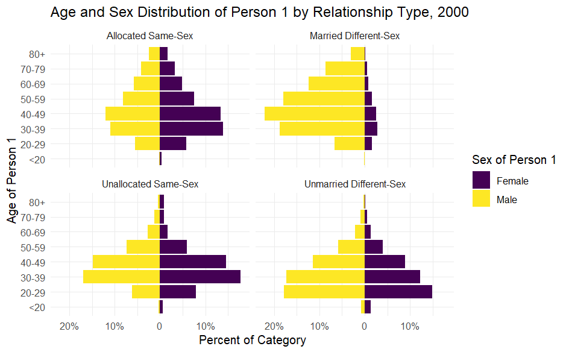

```r
couples %>% mutate(SEX.x = factor(ifelse(SEX.x == 1, "Male", "Female"))) %>%
  filter(YEAR == 2000, PERNUM.x == 1) %>%
  group_by(TYPE) %>%
  count(SEX.x, AGEG) %>%
  mutate(PCT = n/sum(n),
         PCT = ifelse(SEX.x == "Male", 0 - PCT, PCT)) %>%
  ggplot(aes(x = AGEG, y = PCT, fill = SEX.x)) + geom_col() +
  facet_wrap(~TYPE) +
  coord_flip() +
  theme_minimal() +
  theme(legend.position = "right") +
  labs(x = "Age of Person 1", y = "Percent of Category", fill = "Sex of Person 1", title = "Age and Sex Distribution of Person 1 by Relationship Type, 2000") +
  scale_fill_viridis_d() + # these are diff colors
  scale_y_continuous(breaks = seq(-.2, .2, .1), labels = c("20%", "10%", "0", "10%", "20%"))
```

What patterns do you notice and how might you explain them?

> > From the bar graph, we can see that in married couples of different-sex, person 1 is often the male, possibly because of traditional gender roles after marriage, unlike other relationship types. Unmarried different-sex couples tend to be younger because different-sex couples can marry legally so there would be less of them unmarried in older age ranges. Allocated same-sex relationships tend to have older age ranges than unallocated same-sex relationships because typically couples of older age ranges would tend to marry each other.

## Box plots: Distribution of children among couples

**For 2000 only**, for each relationship type, make a box plot showing the distribution of children in the household (`NCHILD.x`). Use the tenth percentile for the bottom whisker and the ninetieth percentile for the top whisker. The x-axis variable will be relationship type and the y-axis variable will be number of children.

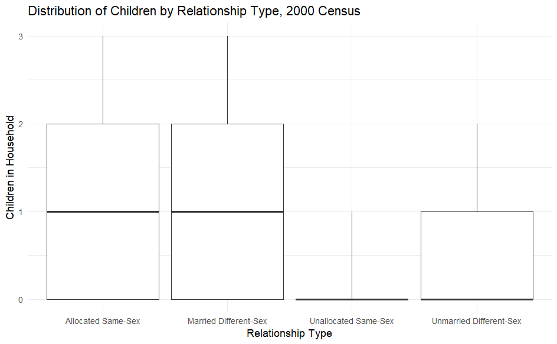

```r
couples %>% filter(YEAR == 2000) %>%
  group_by(TYPE) %>%
  summarize(MIN = quantile(rep(NCHILD.x, PERWT.x), 0.1),
            LOW = quantile(rep(NCHILD.x, PERWT.x), 0.25),
            MED = median(rep(NCHILD.x, PERWT.x)),
            HIGH = quantile(rep(NCHILD.x,PERWT.x), 0.75),
            MAX = quantile(rep(NCHILD.x, PERWT.x), 0.9)) %>%
  ggplot(aes(x = factor(TYPE), ymin = MIN, lower = LOW, middle = MED, upper = HIGH, ymax = MAX)) +
  geom_boxplot(stat = "identity") +
  theme_minimal(base_size = 10) +
  # scale_y_continuous(labels = scales::dollar) +
  # facet_grid(~TYPE) +
  labs(x = "Relationship Type", y = "Children in Household", title = "Distribution of Children by Relationship Type, 2000 Census") +
  scale_fill_brewer()
```

Why do allocated same-sex couples have more children than unallocated same-sex couples?

> > Couples who are actually different sex made errors when classifying their sex when filling in the census form. Therefore, those couples were classified as same-sex couples even though they are different-sex. Married different-sex couples are more likely to have children compared to actual allocated/married same-sex couples. Those actual different-sex couples who made an error to be same-sex couples on the census then all those classified as same-sex couples and married were allocated in the 2000 census. “Allocated Same-sex” here includes those who are actaully different-sex but made an error when filling in sex.

## Alluvial plot: Primary language

Follow the steps below to make an alluvial plot showing whether the members of each couple type speak English as their primary language.

1. Create a factor variable called `LANG` that takes three values: “Both English”, “One English”, “Neither English”, referring to the number of partners who speak English as their primary language. **Test this new variable.**

```r
couples$LANG <- ifelse((couples$LANGUAGE.x == 1 & couples$LANGUAGE.y == 1), "Both English",
                ifelse(couples$LANGUAGE.x == 1 | couples$LANGUAGE.y == 1, "One English", "Neither English"))

#Tests:
  table(couples$LANGUAGE.x, couples$LANG)
```

```
     Both English Neither English One English
  1        981561               0       40183
  2             0            4367        3433
  3             0             707         172
  4             0             584         289
  5             0             181         144
  6             0             102          66
  7             0             186         195
  8             0              17          13
  10            0            3829        2133
  11            0            4655        3106
  12            0           71208       13247
  13            0            2079         355
  14            0             382          24
  15            0              52          70
```

[output cut: 70 more lines]

```r
  table(couples$LANGUAGE.y, couples$LANG)
```

```
     Both English Neither English One English
  0             0              18          40
  1        981561               0       29022
  2             0            4293        4892
  3             0             700         197
  4             0             584         434
  5             0             186         242
  6             0             107         115
  7             0             180         219
  8             0              18          23
  10            0            3778        2228
  11            0            4706        4750
  12            0           71326       16920
  13            0            2100         514
  14            0             390          53
```

[output cut: 71 more lines]

```r
  table(couples$LANGUAGE.x, couples$LANGUAGE.y, couples$LANG)
```

```
, ,  = Both English


          0      1      2      3      4      5      6      7      8     10     11     12     13     14     15     16     17     18     19     20     21     22     23     24     25
  1       0 981561      0      0      0      0      0      0      0      0      0      0      0      0      0      0      0      0      0      0      0      0      0      0      0
  2       0      0      0      0      0      0      0      0      0      0      0      0      0      0      0      0      0      0      0      0      0      0      0      0      0
  3       0      0      0      0      0      0      0      0      0      0      0      0      0      0      0      0      0      0      0      0      0      0      0      0      0
  4       0      0      0      0      0      0      0      0      0      0      0      0      0      0      0      0      0      0      0      0      0      0      0      0      0
  5       0      0      0      0      0      0      0      0      0      0      0      0      0      0      0      0      0      0      0      0      0      0      0      0      0
  6       0      0      0      0      0      0      0      0      0      0      0      0      0      0      0      0      0      0      0      0      0      0      0      0      0
  7       0      0      0      0      0      0      0      0      0      0      0      0      0      0      0      0      0      0      0      0      0      0      0      0      0
  8       0      0      0      0      0      0      0      0      0      0      0      0      0      0      0      0      0      0      0      0      0      0      0      0      0
  10      0      0      0      0      0      0      0      0      0      0      0      0      0      0      0      0      0      0      0      0      0      0      0      0      0
  11      0      0      0      0      0      0      0      0      0      0      0      0      0      0      0      0      0      0      0      0      0      0      0      0      0
  12      0      0      0      0      0      0      0      0      0      0      0      0      0      0      0      0      0      0      0      0      0      0      0      0      0
```

[output cut: 41 more lines]

2. Make an alluvial plot with relationship type on axis 1, `LANG` on axis 2, with fill color also indicating relationship type (there are only two discrete variables in this plot, `TYPE` and `LANG`). Rivers should represent the **percent** of people in each relationship category, so the different values of axis 1 will be the same height.

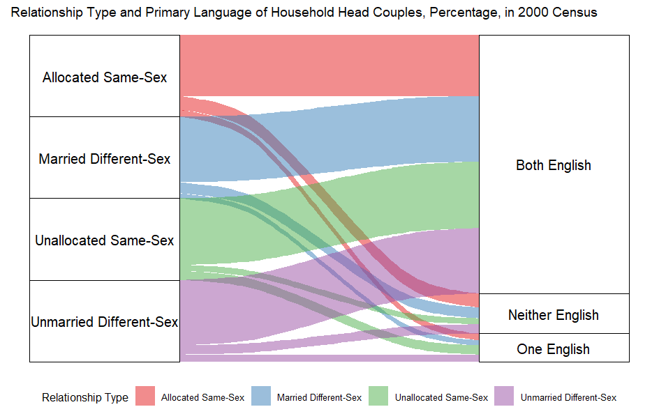

```r
couples %>% filter(YEAR == 2000) %>%
  group_by(TYPE) %>% # out of those who are in each relationship category - denominator
  count(LANG, wt = PERWT.x) %>% # how many of them speak English - numerator
  mutate(PCT = n/sum(n)) %>%
  ggplot(aes(axis1 = TYPE, axis2 = LANG, y = PCT)) +
  geom_alluvium(aes(fill = TYPE)) +
  geom_stratum() + # this will put the boxes into the graph, all of the rivers have one value of mom race
  geom_text(stat = "stratum", aes(label = after_stat(stratum))) + # text goes inside the stratum, the label/value of the text is the same as the stratum (the value of TYPE and LANG become the labels in the stratum)
  theme_void(base_size = 9) + # gets rid of the x and y and axes
  scale_fill_brewer(palette = "Set1") +
  labs(title = "   Relationship Type and Primary Language of Household Head Couples, Percentage, in 2000 Census", fill = "Relationship Type") +
  theme(legend.position = "bottom")
```

```r
couples %>% filter(YEAR == 2000) %>%
  group_by(TYPE) %>% # out of those who are in each relationship category - denominator
  count(LANG, wt = PERWT.x) %>% # how many of them speak English - numerator
  mutate(PCT = n/sum(n)) %>%
  filter(LANG == "One English")
```

| TYPE | LANG | n | PCT |
| --- | --- | --- | --- |
| Allocated Same-Sex | One English | 27501 | 0.08179733 |
| Married Different-Sex | One English | 3479788 | 0.06275499 |
| Unallocated Same-Sex | One English | 35229 | 0.11219462 |
| Unmarried Different-Sex | One English | 401862 | 0.08815943 |

Which relationship type has the highest percentage of couples where at least one member does not speak English as their primary language? Why do you think this is the case?

> > Unallocated Same-sex has the highest percentage of at least one member not speaking English as a primary language. This goes back to the issue of misreporting or miscoding of sex, but this issue may be due to individuals not being familiar with English as their first language. As a result, we see this relationship type having the highest percentage for this condition because individuals who don’t speak English are more prone to making mistakes on the census form.

Please run all of your code, make sure all of your code and output is showing, save your file, and submit `final.nb.html` on Canvas.